# ces() - Complex Exponential Smoothing

Ivan Svetunkov

2019-12-10

This vignette covers `ces()` and `auto.ces()` functions, which are part of smooth package. In this vignette we will use data from `Mcomp` package, so it is advised to install it.

Let’s load the necessary packages:

```r
require(smooth)
require(Mcomp)
```

`ces()` function allows constructing Complex Exponential Smoothing either with no seasonality, or with simple / partial / full seasonality. A simple call for `ces()` results in estimation of non-seasonal model:

For the same series from M3 dataset `ces()` can be constructed using:

```r
ces(M3$N2457$x, h=18, holdout=TRUE, silent=FALSE)
```

```
## Time elapsed: 0.28 seconds
## Model estimated: CES(n)
## a0 + ia1: 1.1085+1.0114i
## Initial values were produced using backcasting.
##
## Loss function type: MSE; Loss function value: 1951898.9225
## Error standard deviation: 1419.223
## Sample size: 97
## Number of estimated parameters: 3
## Number of degrees of freedom: 94
## Information criteria:
##      AIC     AICc      BIC     BICc
## 1686.253 1686.511 1693.977 1694.567
##
## Forecast errors:
## MPE: 15.7%; sCE: -1522.5%; Bias: 76.3%; MAPE: 37.3%
## MASE: 2.635; sMAE: 107.5%; sMSE: 204.4%; rMAE: 1.126; rRMSE: 1.254
```

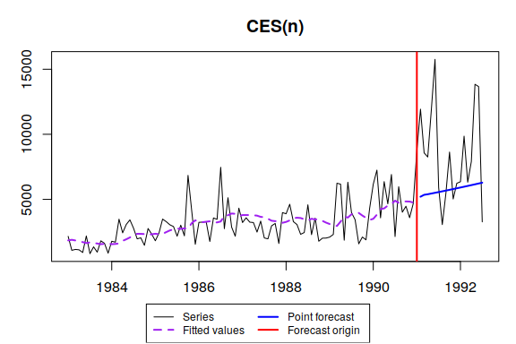

This output is very similar to ones printed out by `es()` function. The only difference is complex smoothing parameter values which are printed out instead of persistence vector in `es()`.

If we want automatic model selection, then we use `auto.ces()` function:

```r
auto.ces(M3$N2457$x, h=18, holdout=TRUE, interval="p", silent=FALSE)
```

```
## Estimating CES with seasonality: "n" "s" "f"
## The best model is with seasonality = "f"
```

```
## Time elapsed: 0.29 seconds
## Model estimated: CES(f)
## a0 + ia1: 1.1276+1.0135i
## b0 + ib1: 0.9943+1.0005i
## Initial values were produced using backcasting.
##
## Loss function type: MSE; Loss function value: 1735277.1936
## Error standard deviation: 1352.622
## Sample size: 97
## Number of estimated parameters: 5
## Number of degrees of freedom: 92
## Information criteria:
##      AIC     AICc      BIC     BICc
## 1678.842 1679.501 1691.715 1693.224
##
## 95% parametric prediction interval was constructed
## 61% of values are in the prediction interval
## Forecast errors:
## MPE: 9.9%; sCE: -1235.6%; Bias: 66.5%; MAPE: 33.7%
## MASE: 2.327; sMAE: 94.9%; sMSE: 167.3%; rMAE: 0.994; rRMSE: 1.135
```

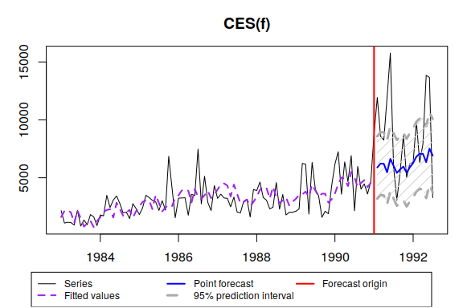

Note that prediction interval are too narrow and do not include 95% of values. This is because CES is pure additive model and it cannot take into account possible heteroscedasticity.

If for some reason we want to optimise initial values then we call:

```r
auto.ces(M3$N2457$x, h=18, holdout=TRUE, initial="o", interval="sp")
```

```
## Time elapsed: 0.79 seconds
## Model estimated: CES(n)
## a0 + ia1: 1.0984+1.0122i
## Initial values were optimised.
##
## Loss function type: MSE; Loss function value: 1940181.3813
## Error standard deviation: 1430.254
## Sample size: 97
## Number of estimated parameters: 5
## Number of degrees of freedom: 92
## Information criteria:
##      AIC     AICc      BIC     BICc
## 1689.668 1690.328 1702.542 1704.050
##
## 95% semiparametric prediction interval was constructed
## 39% of values are in the prediction interval
## Forecast errors:
## MPE: 15.2%; sCE: -1502.3%; Bias: 75.7%; MAPE: 37.3%
## MASE: 2.622; sMAE: 107%; sMSE: 202.9%; rMAE: 1.12; rRMSE: 1.25
```

Now let’s introduce some artificial exogenous variables:

```r
x <- cbind(rnorm(length(M3$N2457$x),50,3),rnorm(length(M3$N2457$x),100,7))
```

`ces()` allows using exogenous variables and different types of prediction interval in exactly the same manner as `es()`:

```r
auto.ces(M3$N2457$x, h=18, holdout=TRUE, xreg=x, xregDo="select", interval="p")
```

```
## Time elapsed: 0.77 seconds
## Model estimated: CES(f)
## a0 + ia1: 1.1276+1.0135i
## b0 + ib1: 0.9943+1.0005i
## Initial values were produced using backcasting.
##
## Loss function type: MSE; Loss function value: 1735277.1936
## Error standard deviation: 1355.907
## Sample size: 97
## Number of estimated parameters: 5
## Number of degrees of freedom: 92
## Information criteria:
##      AIC     AICc      BIC     BICc
## 1678.842 1679.501 1691.715 1693.224
##
## 95% parametric prediction interval was constructed
## 67% of values are in the prediction interval
## Forecast errors:
## MPE: 9.9%; sCE: -1232.7%; Bias: 66.4%; MAPE: 33.7%
## MASE: 2.325; sMAE: 94.8%; sMSE: 166.8%; rMAE: 0.993; rRMSE: 1.133
```

The same model but with updated parameters of exogenous variables is called:

```r
auto.ces(M3$N2457$x, h=18, holdout=TRUE, xreg=x, updateX=TRUE, interval="p")
```

```
## Time elapsed: 4.06 seconds
## Model estimated: CESX(s)
## a0 + ia1: 1.0555+1.0363i
## Initial values were produced using backcasting.
## Xreg coefficients were estimated in a crazy style
##
## Loss function type: MSE; Loss function value: 1677807.8248
## Error standard deviation: 1375.649
## Sample size: 97
## Number of estimated parameters: 11
## Number of degrees of freedom: 86
## Information criteria:
##      AIC     AICc      BIC     BICc
## 1687.575 1690.681 1715.897 1723.001
##
## 95% parametric prediction interval was constructed
## 50% of values are in the prediction interval
## Forecast errors:
## MPE: 23%; sCE: -1749.9%; Bias: 87%; MAPE: 36.6%
## MASE: 2.718; sMAE: 110.9%; sMSE: 218.1%; rMAE: 1.161; rRMSE: 1.295
```